# Distance metrics and clustering

### Hierarchical clustering with hclust

Euclidean distance is rarely used in the context of microarray analysis. A distance based on Pearson’s correlation coefficient is most generally preferred (Spearman’s rank correlation coefficient may also be used). Let’s visualize the sample-sample correlation matrix using a heatmap.

<< Hide | Show >>

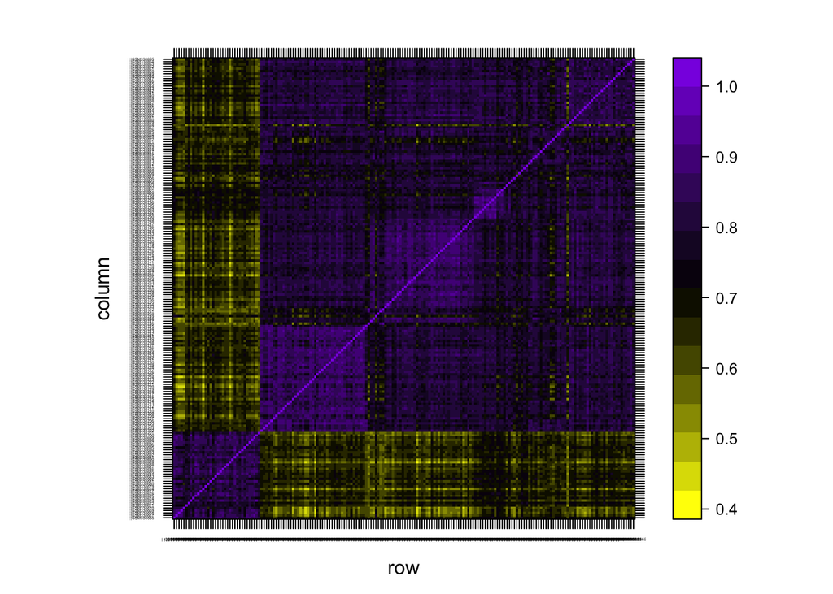

```r
pear <- cor(data, method="pearson")
palette <-colorRampPalette(c("yellow", "black","blueviolet"))
library(lattice)
levelplot(pear,col.regions=palette, scales=list(cex=0.2))
```

```r
# we can also store the result as a high quality pdf file
pdf("coor.pdf"); levelplot(pear,col.regions=palette, scales=list(cex=0.2)); dev.off()
```

The Pearson’s correlation coefficient is bounded between -1 and 1. We can transform it into a distance using the following command:

```r
pear.dist <- as.dist((1-pear)/2)
```

Using this distance matrix use the hclust function to perform hierarchical clustering of samples.

<< Hide | Show >>

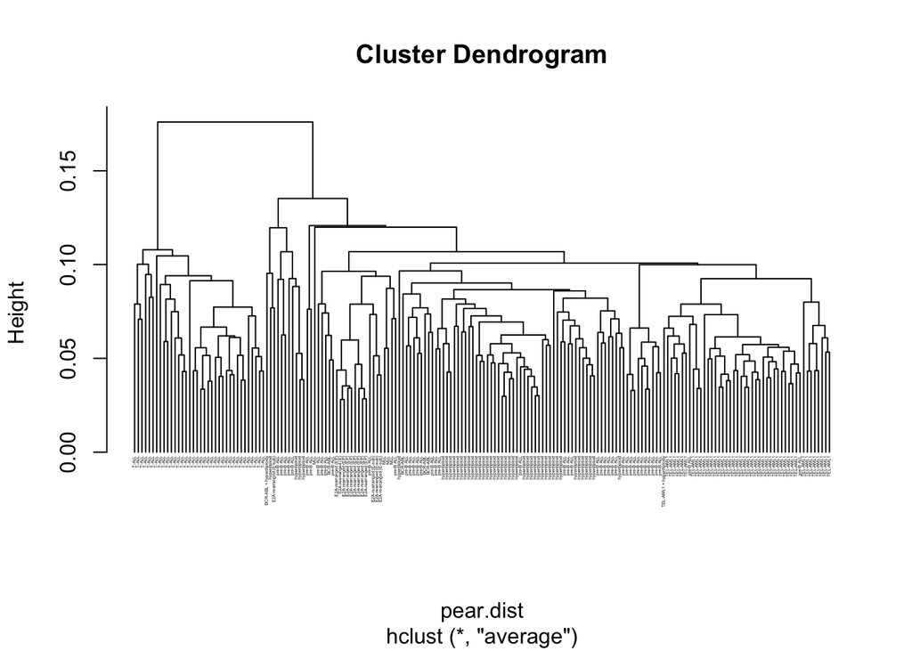

```r
hp <- hclust(pear.dist, method="average")
plot(hp, hang=-1, labels=as.character(pheno$Sample.title), cex=0.2)
```

```r
# we can also store the result as a high quality pdf file
pdf("hp.pdf")
plot(hp, hang=-1, labels=as.character(pheno$Sample.title), cex=0.2)
dev.off()
```

```r
#system("evince hp.pdf&")
```

The objects resulting from *hclust* calls can also be used to construct a heatmap. This can be done for instance using the *heatmap.3* function. Again, take care to the arguments used to construct the tree.

<< Hide | Show >>

[output not shown]

[output not shown]

[output not shown]

[output not shown]

[figure not shown]

[output not shown]

```r
library("GMD")
library("RColorBrewer")

# Median center rows
data.med.center <- sweep(data, MARGIN=1, STATS=apply(data,1,median), FUN = "-",)
# floor and ceil

data.med.center[ data.med.center > 5 ] <- 5
data.med.center[ data.med.center < -5 ] <- -5

# Compute hierarchical clustering trees for rows and columns
pear.cols <- cor(t(data.med.center), method="pearson")
pear.dist <- as.dist((1-pear.cols)/2)
hc.cols <- hclust(pear.dist, method="average")
pear.rows <- cor(data.med.center, method="pearson")
pear.dist <- as.dist((1-pear.rows)/2)
hc.rows <- hclust(pear.dist, method="average")

# Prepare a function that returns interpolated color sets
col.fun = colorRampPalette(c("green", "black", "red"))



library("GMD")
library("RColorBrewer")

x11(height=14, width=14)
heatmap.3(t(data.med.center),
          scale="none",
          RowIndividualColors = pheno.vec.col,
          cluster.by.col=TRUE,
          cluster.by.row=TRUE,
          Rowv=TRUE,
          Colv=TRUE,
          hclust.col = hc.cols,
          hclust.row = hc.rows,
          labRow=pheno.vec,
          labCol=NULL,
          cexRow = 0.5,
          color.FUN = col.fun)
```

```r
dev.off()
```

However, one can see the limits of using R in this context…

### Hierarchical clustering with the cluster and treeview software

R is not particularly well-suited to visualize classification results for very large datasets. We will thus install the cluster and treeview software that are very handy to browse the results of a hierarchical clustering.

<< Hide | Show >>

```bash
# These are shell/bash commands !
mkdir -p ~/bin
cd ~/bin
wget http://bonsai.hgc.jp/~mdehoon/software/cluster/cluster-1.50.tar.gz
tar xvfz cluster-1.50.tar.gz
cd cluster-1.50
./configure --without-x
make
echo -e "\nalias cluster=$PWD/src/cluster" >> ~/.bashrc
cd ..
wget http://sourceforge.net/projects/jtreeview/files/jtreeview/1.1.6r2/TreeView-1.1.6r2-bin.tar.gz
tar xvfz TreeView-1.1.6r2-bin.tar.gz
echo "alias javatreeview='java -jar  $PWD/TreeView-1.1.6r2-bin/TreeView.jar'" >> ~/.bashrc
source  ~/.bashrc
cd -
```

Using the cluster software, run hierarchical clustering on both genes and samples.

<< Hide | Show >>

```bash
cluster -f GSE13425_sub_1.txt -g 2 -e 2 -m a  -cg m
javatreeview
```

Now you can open the .cdt file, that was produced by cluster using javatreeview. How are the samples classified ? What can you say about gene classification ?

### Kmeans clustering with R

Look at the tree produced by Treeview. How many classes would you guess from this tree. Use the *Kmeans()* function from the amap package to perform a kmeans with the number of classes you guessed from the hierachical clustering. Look carefully at the parameters. What is the default distance used here ? Is that the right distance to use in this context ? Use the *matplot()* function to draw the profiles of each classes. Compare you results with other students (that may have choosen a different number of classes).

<< Hide | Show >>

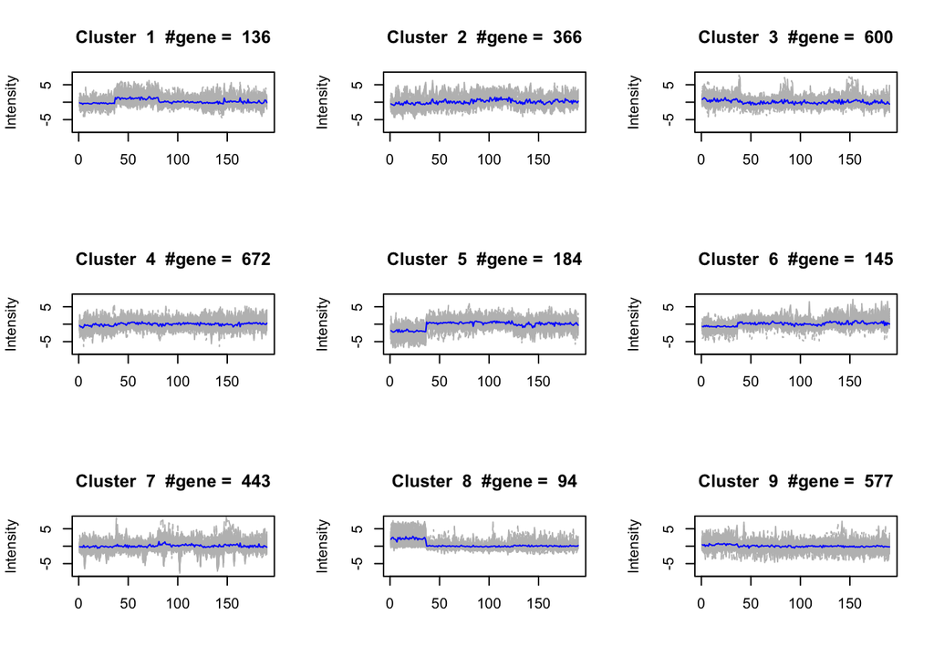

```r
## Reading the file (if required)
data <- read.table("GSE13425_sub_with_pheno.txt", sep="\t", head=T, row.names = 1)

## Performing Kmeans
library(amap)
k <- 9
km <- Kmeans(data, centers=k, method="pearson", iter.max = 100)

par(mfrow=c(3,3))
for(i in 1:k){

  cluster_k <- data[names(km$cluster[km$cluster==i]),]
  cluster_k <- sweep(cluster_k,
                     MARGIN = 1,
                     FUN = "-",
                     STATS = apply(cluster_k, 1, median))
  matplot(t(cluster_k),
          type="l",
          col="gray",
          ylab="Intensity",
          ylim=c(-8,8),
          main=paste("Cluster ", i, " #gene = ", nrow(cluster_k)))
  matpoints(colMeans(cluster_k), type="l", col="blue")
}
```

Perform the same clustering using the kmeans version implemented in cluster 3.0. Load the results in Java Treeview.

**NB**: if required, the filtered dataset can be obtained here.